# Dimension Reduction using Principal Components

#### Generate hypothetical data

Copied from lecture notes.

```r
set.seed(456)
library(MASS)
m <- c(100, 50)
s <- matrix(c(100, sqrt(.5*100*50), sqrt(.5*100*50), 50), nrow=2)
data <- data.frame(mvrnorm(n=100, mu=m, Sigma=s))
colnames(data) <- c("X1", "X2")
```

##### On Your Own

1. **Confirm the total variance in the hypothetical example is preserved by calculating the sum of the variances for each $X_{1}$ and $X_{2}$, and $C_{1}$ and $C_{2}$.**

```r
pr <- princomp(data)
var(data$X1) + var(data$X2)
```

```
## [1] 149.3367
```

```r
sum(pr$sdev^2)
```

```
## [1] 147.8434
```

The total variance in the data X’s has been preserved. This is seen by the total variance in the data X’s being equal to the total variances in the PC’s. While not identically equal, the total variance in the PC’s is 99% of the total variance in the X’s.

2. **Confirm the total variance of the principal components when using the correlation matrix is equal to the number of principal components.**

```r
pr_corr <- princomp(data, cor=TRUE)
sum(pr_corr$sdev^2)
```

```
## [1] 2
```

There are two PC’s, and the total variance of the PC’s is equal to 2.

3. **According to the PCA How-To manual by Emily Mankin, what are the two Principles of PCA?**
   1. PCA Principle 1: In general high correlation between variables is a telltale sign of high redundancy in the data.
   2. PCA Principle 2: The most important dynamics are the ones with the largest variance.
4. **PCA vs FA**
   1. **In your own words, what is the differnce between PCA and FA?**

   Principal components is a method of creating linear combinations of existing variables where the new variables are pairwise independent and fewer PC’s can explain most of the variance in the data.

   Factor analysis is used when there is a theoretical underlying latent construct (latent factor) driving the measured data responses. Factor analysis is used to predict the responses on the measured data based on these latent constructs.
   2. **Explain what is meant by a “latent factor”.** A latent factor or latent construct is a characteristic of a person that you wish to know something about, but is directly unmeasurable. Examples include a persons grit or preserverance, their level of parental bonding or community engagement.
5. For the depression data set, perform a PCA on the last seven variables `DRINK - CHRONILL`. Interpret the results.

```r
depress  <- read.delim("C:/GitHub/MATH456/data/depress_030816.txt")
dep_data <- depress[,31:37]
```

Calculate the PC’s using the correlation matrix.

```r
pc_dep  <- princomp(dep_data, cor=TRUE)
```

How much variance is explained by each PC?

[figure not shown]

```r
qplot(x=1:7, y=cumsum(pc_dep$sdev^2)/sum(pc_dep$sdev^2)*100,
           geom=c("point", "line"), main="Covariance") +
     xlab("PC number") + ylab("Cumulative %") + geom_hline(aes(yintercept=75)) + ylim(c(0,100))
```

We select four eigenvectors based on a cut off of 75% cumulative percent of variance explained.

Examine the factor loadings of the first four PC’s to see if they can be interpreted.

We can look directly at the loading matrix

```r
pc_dep$loadings[,1:4]
```

```
##              Comp.1      Comp.2      Comp.3     Comp.4
## DRINK    -0.1702159  0.28750034  0.67474463  0.5036658
## HEALTH   -0.4586822  0.27112027  0.25234850 -0.1284490
## REGDOC    0.1243683 -0.34287335  0.54694925 -0.6987616
## TREAT     0.5066427 -0.07758864  0.32899234  0.1888948
## BEDDAYS  -0.3763927 -0.52443681  0.22133098  0.1373967
## ACUTEILL -0.2553766 -0.63729571 -0.13138837  0.3234153
## CHRONILL -0.5306545  0.19767508 -0.08602421 -0.2870494
```

Or we can create a visualization. First I turn the loading matrix into a named data frame.

```r
library(reshape2)
dep_cov <- data.frame(pc_dep$loadings[,1:4])
melt_dcov <- cbind(x=names(dep_data), melt(dep_cov))
head(melt_dcov)
```

```
##          x variable      value
## 1    DRINK   Comp.1 -0.1702159
## 2   HEALTH   Comp.1 -0.4586822
## 3   REGDOC   Comp.1  0.1243683
## 4    TREAT   Comp.1  0.5066427
## 5  BEDDAYS   Comp.1 -0.3763927
## 6 ACUTEILL   Comp.1 -0.2553766
```

Then create a barplot using the `value` as the heights of the bars, one panel per `variable` (principal component) and one bar per `x` (individual variable).

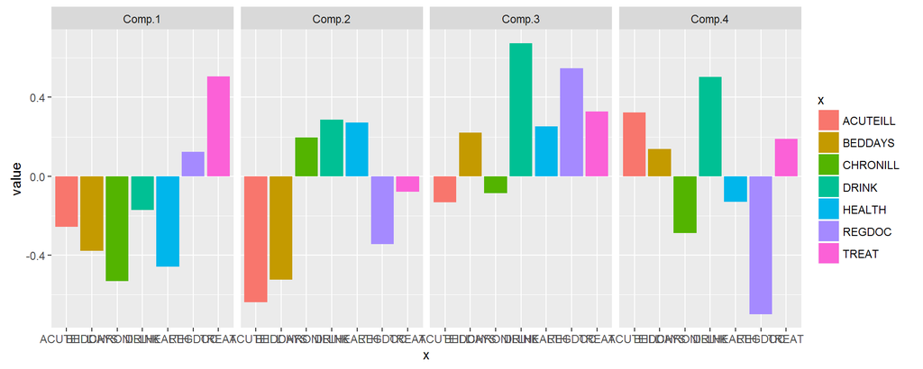

```r
ggplot(data=melt_dcov) +
  geom_bar(aes(x=x, y=value, fill=x), stat="identity") +
  facet_wrap(~variable, ncol=4)
```

Since we are using the correlation matrix to create the eigenvalues, we can directly calculate the correlation between the individual variables and each principal component. The strength and direction of the correlation corresponds to the direction and magnitude of the factor loading. However, the correlation is directly interpretable where as the factor loading is not.

```r
pcload <-  matrix(pc_dep$loadings[,1:4], nrow=7)
cor_PC_X <- matrix(rep(NA, 28), nrow=7, dimnames=list(names(dep_data), c("PC1", "PC2", "PC3", "PC4")))
for(i in 1:4){
  for(j in 1:7){
    cor_PC_X[j,i] <- pcload[j,i] %*% matrix(pc_dep$sdev)[i]
 }
}
print(xtable(cor_PC_X, digits=3), type="html")
```

|  | PC1 | PC2 | PC3 | PC4 |
| --- | --- | --- | --- | --- |
| DRINK | -0.241 | 0.334 | 0.684 | 0.484 |
| HEALTH | -0.649 | 0.315 | 0.256 | -0.123 |
| REGDOC | 0.176 | -0.399 | 0.554 | -0.671 |
| TREAT | 0.717 | -0.090 | 0.333 | 0.182 |
| BEDDAYS | -0.532 | -0.610 | 0.224 | 0.132 |
| ACUTEILL | -0.361 | -0.741 | -0.133 | 0.311 |
| CHRONILL | -0.751 | 0.230 | -0.087 | -0.276 |

Using anything over .5 as an indication of “strong” correlation, `TREAT` is strongly positivly with the first prinicipal component, and `CHRONILL`, `HEALTH`, `BEDDAYS` are all strongly negatively correlated with PC1.

*It is key here to have the codebook open so you know what the variables mean, and what a higher value on each variable is interpreted as.* In general, for all these variables a higher outcome indicates poorer health.

Summary:

- The first eigenvector is comprised of `health`, `treat`, `chronill`, `beddays`.
- The second eigenvector consists of `beddays` and `acuteill`.
- The third consists of `drink` and `regdoc`.
- The fourth consists of just `regdoc`.

A possible interpretation could be poor health for the first eigenvector, recently sick for the second eigenvector, healthy lifestyle for the third, and regular doctor visits for the fourth.

6. **Using the family lung function data perform a PCA on mother’s height, weight, age, FEV1, and FVC. Use the covariance matrix, then repeat using the correlation matrix. Compare the results and comment.**

Read in the data and extract just the variables of interest.

```r
lung <- read.delim("C:/GitHub/MATH456/data/Lung_020716.txt")
pc_lungdata <- lung[,c('MHEIGHT', 'MWEIGHT', 'MAGE', 'MFEV1', 'MFVC')]
```

To look at the correlation matrix for the X’s to get an idea of what variables are correlated, I could use the `cor(pc_lungdata)` function but I would also like to get the pairwise p-values for a test of significant correlation. This can be obtained by using the `rcorr` function in the `Hmisc` package.

```r
library(Hmisc)
rcorr(as.matrix(pc_lungdata), type="pearson")
```

```
##         MHEIGHT MWEIGHT  MAGE MFEV1  MFVC
## MHEIGHT    1.00    0.32  0.02  0.46  0.50
## MWEIGHT    0.32    1.00  0.00  0.20  0.20
## MAGE       0.02    0.00  1.00 -0.27 -0.19
## MFEV1      0.46    0.20 -0.27  1.00  0.90
## MFVC       0.50    0.20 -0.19  0.90  1.00
##
## n= 150
##
##
## P
##         MHEIGHT MWEIGHT MAGE   MFEV1  MFVC
## MHEIGHT         0.0000  0.8396 0.0000 0.0000
## MWEIGHT 0.0000          0.9518 0.0124 0.0161
## MAGE    0.8396  0.9518         0.0009 0.0212
## MFEV1   0.0000  0.0124  0.0009        0.0000
## MFVC    0.0000  0.0161  0.0212 0.0000
```

This shows that height is significantly correlated with weight, FEV1 and FVC, weight is correlated with FEV1 and FVC, AGE is correlated with FEV1 and FVC, and fev1 and fvc are also highly correlated. This is a perfect situation for PCA!

Create PC’s using the covariance and correlation matricies separately.

```r
lung_pc_cov <- princomp(pc_lungdata)
lung_pc_corr <- princomp(pc_lungdata, cor=TRUE)
```

Assess the amount of variance explained per PC for each model. We can see the cumulative % of variance explained by looking at the output directly,

```r
summary(lung_pc_cov)
```

```
## Importance of components:
##                            Comp.1     Comp.2      Comp.3       Comp.4       Comp.5
## Standard deviation     60.6565146 30.0576990 6.569887292 2.0416024978 2.055623e-01
## Proportion of Variance  0.7946375  0.1951307 0.009322448 0.0009002363 9.126433e-06
## Cumulative Proportion   0.7946375  0.9897682 0.999090637 0.9999908736 1.000000e+00
```

```r
summary(lung_pc_corr)
```

```
## Importance of components:
##                           Comp.1    Comp.2    Comp.3    Comp.4     Comp.5
## Standard deviation     1.5590904 1.0534546 0.9134006 0.7274381 0.30984462
## Proportion of Variance 0.4861525 0.2219533 0.1668601 0.1058332 0.01920074
## Cumulative Proportion  0.4861525 0.7081059 0.8749660 0.9807993 1.00000000
```

Or we can create a visualization.

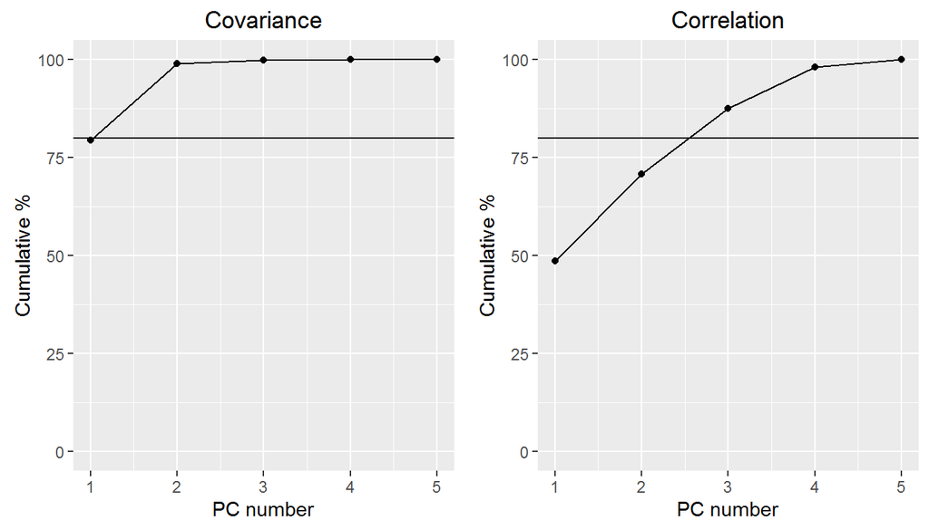

```r
a <- qplot(x=1:5, y=cumsum(lung_pc_cov$sdev^2)/sum(lung_pc_cov$sdev^2)*100,
           geom=c("point", "line"), main="Covariance") +
     xlab("PC number") + ylab("Cumulative %") + geom_hline(aes(yintercept=80)) + ylim(c(0,100))

b <- qplot(x=1:5, y=cumsum(lung_pc_corr$sdev^2)/5*100, geom=c("point", "line"), main="Correlation") +
     xlab("PC number") + ylab("Cumulative %") + geom_hline(aes(yintercept=80))+ ylim(c(0,100))

library(gridExtra)
grid.arrange(a, b, nrow=1)
```

- Using the covariance matrix, one principal component accounts for approximately 79% of the data, and two explain 99% of the data.
- Using the correlation matrix, we see that three principal components are derived accounting for approximately 87.5% of the variance among the original variables.

Decide on a rough number of PC’s to keep by making a screeplot.

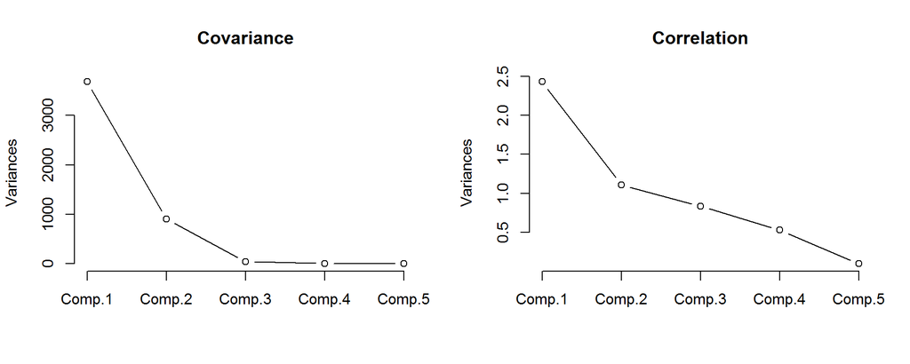

```r
par(mfrow=c(1,2))
screeplot(lung_pc_cov, type="lines", main="Covariance")
screeplot(lung_pc_corr, type="lines", main="Correlation")
```

Examine the factor loadings and see if the PC’s can be interpreted. We could look at the matrix directly,

```r
lung_pc_cov$loadings
```

```
##
## Loadings:
##         Comp.1 Comp.2 Comp.3 Comp.4 Comp.5
## MHEIGHT                       0.999
## MWEIGHT -0.133 -0.991
## MAGE                  -0.999
## MFEV1                               -1.000
## MFVC    -0.991  0.133
##
##                Comp.1 Comp.2 Comp.3 Comp.4 Comp.5
## SS loadings       1.0    1.0    1.0    1.0    1.0
## Proportion Var    0.2    0.2    0.2    0.2    0.2
## Cumulative Var    0.2    0.4    0.6    0.8    1.0
```

Or we can create a visualization. First I turn the loading matrix into a named data frame.

```r
library(reshape2)
pc_cov_df <- data.frame(lung_pc_cov$loadings[,1:5])
melt_cov <- cbind(x=names(pc_lungdata), melt(pc_cov_df))
head(melt_cov)
```

```
##         x variable        value
## 1 MHEIGHT   Comp.1 -0.020844744
## 2 MWEIGHT   Comp.1 -0.132577474
## 3    MAGE   Comp.1  0.020624287
## 4   MFEV1   Comp.1 -0.007205914
## 5    MFVC   Comp.1 -0.990712584
## 6 MHEIGHT   Comp.2 -0.015684948
```

Then create a barplot using the `value` as the heights of the bars, one panel per `variable` (principal component) and one bar per `x` (individual variable).

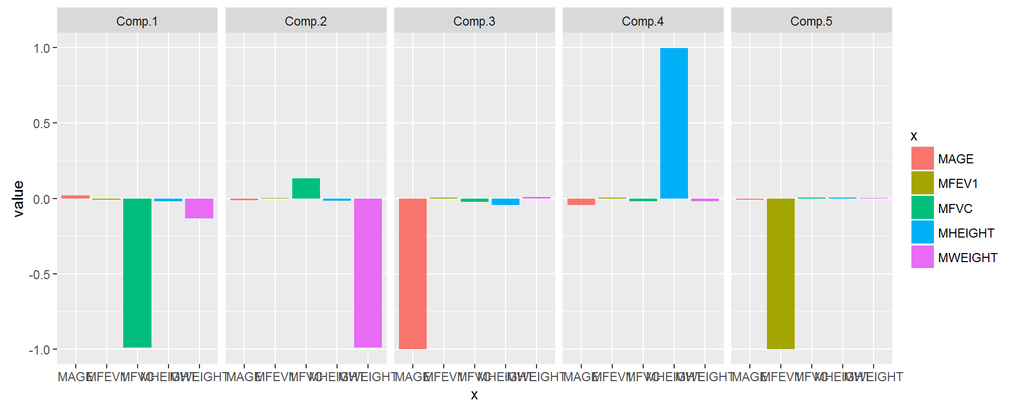

```r
ggplot(data=melt_cov) +
  geom_bar(aes(x=x, y=value, fill=x), stat="identity") +
  facet_wrap(~variable, ncol=5)
```

- Each PC seems to represent a single variable. This does not aid us well as a dimension reduction tool.
- PC1 and PC2 still explain 99% of the variance in the data, and these seem to only contain information from FVC and WEIGHT.

Now do the same for the correlation model.

```r
pc_cor_df <- data.frame(lung_pc_corr$loadings[,1:5])
melt_cor <- cbind(x=names(pc_lungdata), melt(pc_cor_df))
head(melt_cor)
```

```
##         x variable      value
## 1 MHEIGHT   Comp.1 -0.4529875
## 2 MWEIGHT   Comp.1 -0.2643182
## 3    MAGE   Comp.1  0.1810662
## 4   MFEV1   Comp.1 -0.5883823
## 5    MFVC   Comp.1 -0.5881832
## 6 MHEIGHT   Comp.2 -0.3650768
```

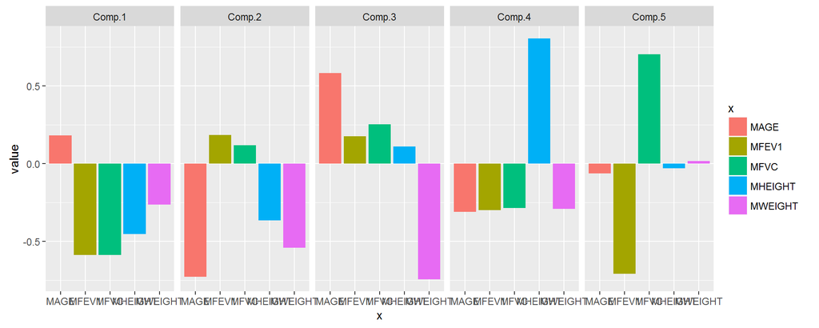

```r
ggplot(data=melt_cor) +
  geom_bar(aes(x=x, y=value, fill=x), stat="identity") +
  facet_wrap(~variable, ncol=5)
```

- Principal component 1 has substantial negative loadings of mother’s height, FEV1, and FVC.
- Principal component 2 and 3 both have substantial loadings by mother’s weight and age, the difference is that both age and weight are negativly associated with PC2, but age is positivly associated with PC3.

**Summary**

Using the covariance matrix appears to be a better choice since ideally we would like as few principal components as possible to account for as much variation among the variables as possible. Furthermore the way the variables load onto the PC’s created by the covariance matrix are easier to iterpret.